# distr6: R6 Object-Oriented Probability Distributions Interface in R

## Composite distribution modeling

Composite distributions are an essential part of any distribution software. The following example demonstrates two types of composites: composition via distribution transformation (truncation) and composition via mixtures and vectors.  
First, a Binomial distribution is constructed and truncated between $1$ and $5$, the CDF of the new distribution is queried.

```r
> TB <- truncate(
   Binomial$new(size = 20, prob = 0.5),
   lower = 1,
   upper = 5
   )
> round(TB$cdf(0:6), 4)
[1] 0.0000 0.0000 0.0088 0.0613 0.2848 1.0000 1.0000
```

Next, a vector distribution is constructed of two Normal distributions, with respective means $1$ and $2$ and unit standard deviation. The parameters are queried (some columns suppressed).

```r
> V <- VectorDistribution$new(distribution = "Normal",
+                             params = data.frame(mean = 1:2))
> V$parameters()
           id value support
1: Norm1_mean     1       R
2:  Norm1_var     1      R+
3:   Norm1_sd     1      R+
4: Norm1_prec     1      R+
5: Norm2_mean     2       R
6:  Norm2_var     1      R+
7:   Norm2_sd     1      R+
8: Norm2_prec     1      R+
```

Vectorization is possible across distributions, samples, and both. In the example below, the first call to `$pdf` evaluates both distributions at (1, 2), the second call evaluates the first at (1) and the second at (2), and the third call evaluates the first at (1, 2) and the second at (3, 4).

```r
> V$pdf(1:2)
       Norm1     Norm2
1: 0.3989423 0.2419707
2: 0.2419707 0.3989423
> V$pdf(1, 2)
       Norm1     Norm2
1: 0.3989423 0.3989423
> V$pdf(1:2, 3:4)
       Norm1      Norm2
1: 0.3989423 0.24197072
2: 0.2419707 0.05399097
```

Finally, a mixture distribution with uniform weights is constructed from a $Normal(2, 1)$ distribution and an $Exponential(1)$.

```r
> MD <- MixtureDistribution$new(
+   list(Normal$new(mean = 2, sd = 1),
+        Exponential$new(rate = 1)
+   )
+ )
> MD$pdf(1:5)
[1] 0.304925083 0.267138782 0.145878896 0.036153303 0.005584898
> MD$cdf(1:5)
[1] 0.3953879 0.6823324 0.8957788 0.9794671 0.9959561
> MD$rand(5)
[1] 3.6664473 0.1055126 0.6092939 0.8880799 3.4517465
```

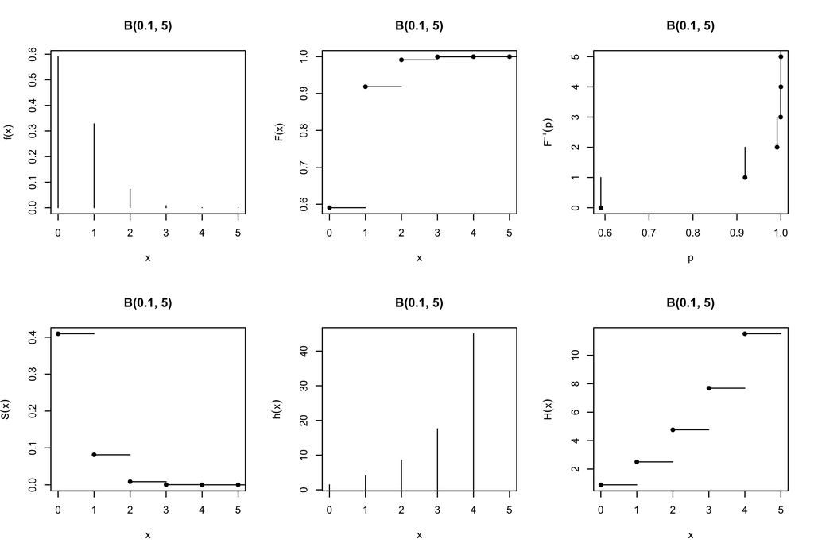

Figure 6: Visualizing a Binomial(0.1, 5) distribution, `b`, with `plot(b, fun = "all")`. Functions clockwise from top-left: probability mass, cumulative distribution, quantile (inverse cdf), cumulative hazard, hazard, and survival.

# Future work

Whilst *distr6* fulfils its primary purpose as an R6 interface for probability distributions with basic features, it is not consider ‘feature-complete’, as it currently lacks many of the important features included in *distr* and other related software. *distr6* is in constant development and has an active [GitHub](https://github.com/alan-turing-institute/distr6) with open issues and projects. Some concrete short-term goals include:

- A more generalized convolution interface
- Expanding truncation to other interval types (currently only left-open is supported)
- Extending the `FunctionImputation` decorator to work on higher-order distributions as well as to improve speed and accuracy.
- Exposing further internal functionality for more user-control over numerical results.

# Summary

*distr6* introduces a robust and scalable object-oriented interface for probability distributions to R and aims to be the first-stop for class object-oriented probability distributions in R. By making use of R6, every implemented distribution is clearly defined with properties, traits, and analytic results. Whilst R *stats* is limited to very basic `dpqr` functions for representing evaluated distributions, *distr6* ensures that probability distributions are treated as complex mathematical objects.

Future updates of the package will include adding further numerical approximation strategies in the decorators to allow users to choose different methods (instead of being forced to use one). Additionally, the extensions to R6 could be abstracted into an independent package in order to better benefit the R community.

*distr6* is released under the MIT license on [GitHub](https://github.com/alan-turing-institute/distr6) and [CRAN](https://CRAN.R-project.org/package=distr6). Extended documentation, tutorials, and examples are available at https://alan-turing-institute.github.io/distr6/. Code quality is monitored and maintained by an extensive suite of unit tests on multiple continuous integration systems.

# Acknowledgments

We would like to thank and acknowledge Prof. Dr. Peter Ruckdeschel and Prof. Dr. Matthias Kohl for their work on the *distr* package and for extensive discussions, planning, and design decisions that were utilised in the development of *distr6*. RS receives a PhD stipend from EPSRC (EP/R513143/1).

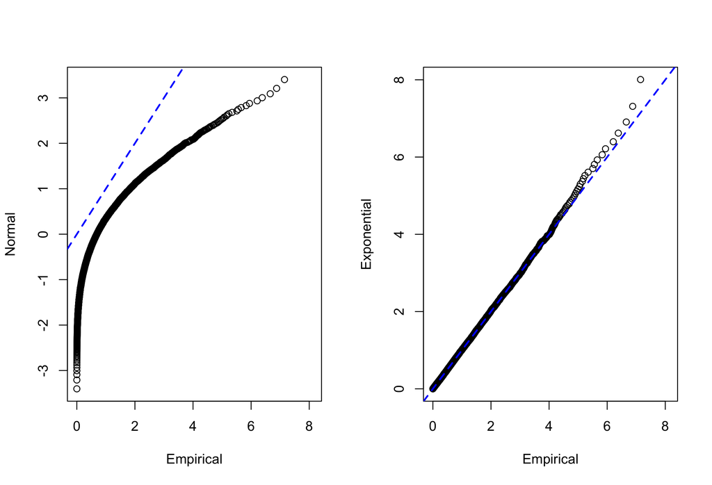

Figure 7: Q-Q plots comparing an unknown Empirical distribution, `E`, to theoretical Normal (left) and Exponential (right) distributions with `qqplot(E, Normal$new()` and `qqplot(E, Exponential$new()` respectively.

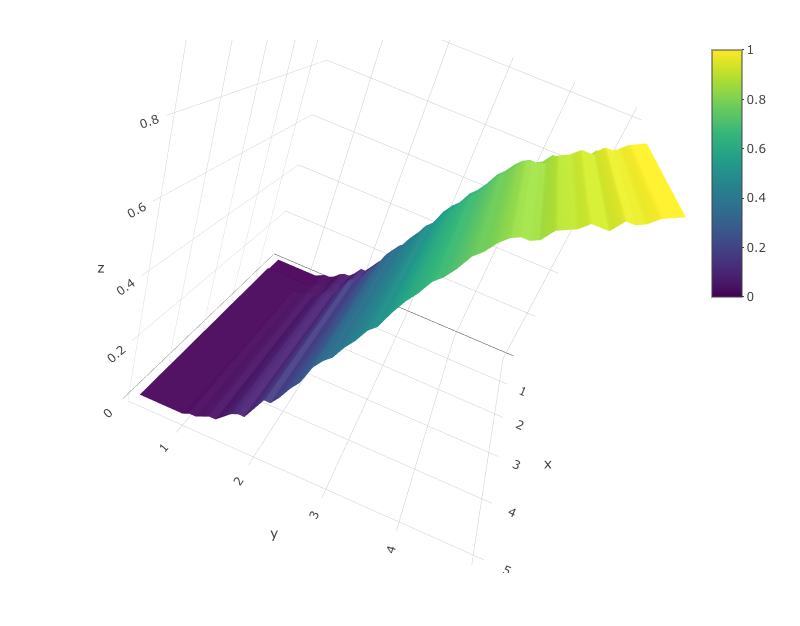

Figure 8: Visualizing a bivariate empirical distribution, `E`, with `plot("E", fun = "cdf")`.

Chambers, John M. 2014. “Object-Oriented Programming, Functional Programming and R.” *Statist. Sci.* 29 (2): 167–80. https://projecteuclid.org:443/euclid.ss/1408368569.

Chang, Winston. 2018. “R6: Classes with Reference Semantics.” https://cran.r-project.org/package=R6.

Dutang, Christophe, Vincent Goulet, and Mathieu Pigeon. 2008. “actuar: An R Package for Actuarial Science.” *Journal of Statistical Software* 25 (7): 38.

Eddelbuettel, Dirk, and Romain Francois. 2011. “Rcpp: Seamless R and C++ Integration.” *Journal of Statistical Software* 40 (8): 1–18. http://www.jstatsoft.org/v40/i08/.

Gamma, E, R Helm, R Johnson, and J Vlissides. 1996. “[Design Patterns: Elements of Reusable Software](https://www.ncbi.nlm.nih.gov/pubmed/22693012).”

Hayes, Alex, and Ralph Moller-Trane. 2019. “distributions3: Probability Distributions as S3 Objects.” CRAN. https://cran.r-project.org/package=distributions3.

Király, Franz J., Markus Löning, Anthony Blaom, Ahmed Guecioueur, and Raphael Sonabend. 2021. “Designing Machine Learning Toolboxes: Concepts, Principles and Patterns.” *arXiv*, January. http://arxiv.org/abs/2101.04938.

Lin, Dahua, John Myles White, Simon Byrne, Douglas Bates, Andreas Noack, John Pearson, Alex Arslan, et al. 2019. “JuliaStats/Distributions.jl: a Julia package for probability distributions and associated functions.” https://doi.org/10.5281/zenodo.2647458.

Mersmann, Olaf. 2019. “microbenchmark: Accurate Timing Functions.” CRAN. https://cran.r-project.org/package=microbenchmark.

O’Hara-Wild, Mitchell, and Alex Hayes. 2020. “distributional: Vectorised Probability Distributions.” CRAN. https://cran.r-project.org/package=distributional.

Ruckdeschel, Peter, Matthias Kohl, Thomas Stabla, and Florian Camphausen. 2006. “S4 Classes for Distributions.” R News. https://cran.r-project.org/package=distr.

Sablica, Lukas, and Kurt Hornik. 2020. “mistr: A Computational Framework for Mixture and Composite Distributions.” *The R Journal* 12 (1): 283. https://doi.org/10.32614/RJ-2020-003.

Sonabend, Raphael. 2019. “R62S3: Automatic Method Generation from R6.” CRAN. https://cran.r-project.org/package=R62S3.

Sonabend, Raphael, and Franz J. Kiraly. 2020. “set6: R6 Mathematical Sets Interface.” *Journal of Open Source Software* 5 (55): 2598. https://doi.org/10.21105/joss.02598.

Wolodzko, Tymoteusz. 2019. “extraDistr: Additional Univariate and Multivariate Distributions.” CRAN. https://cran.r-project.org/package=extraDistr.

[^1]: http://adv-r.had.co.nz/OO-essentials.html